# MECH481A6: Engineering Data Analysis in R

Chapter 9 Homework: Transformations

Genevieve Reyland-Slawson

31 October, 2023

# Load packages

```r
# load packages for current session
library(tidyverse)
library(gridExtra) # or library(patchwork) for arranging figures
library(MASS) # for fitting distributions to your data
```

# Chapter 9 Homework

This homework will give you practice at transforming and visualizing data and fitting a distribution to a set of data. Note that much of the code needed to complete this homework can be adapted from the [Coursebook Exercises](https://smogdr.github.io/edar_coursebook/transform.html#ch-9-exercises) in Chapter 9.

When a question asks you to make a plot, remember to set a theme, title, subtitle, labels, colors, etc. It is up to you how to personalize your plots, but put in some effort and make the plotting approach consistent throughout the document. For example, you could use the same theme for all plots.

## Question 1

Recreate Figure 9.8 (the three EDA plots based on `salary_ps2$salary`), but show the plots on a log-scale x-axis. Plot the histogram with 30 bins and move the legends so that they don’t block the data. Does the data in these plots appear more symmetric about the median? Why or why not?

```r
salary_csv <- "/Users/genevieve/Reyland-MECH476/data/salary_ch9.csv"
salary_ps <- read_csv(file = salary_csv)

salary_ps %>%
  group_by(sex) %>%
  summarise(median = median(salary),
            mean = mean(salary),
            min = min(salary),
            max = max(salary),
            IQR = IQR(salary),
            .groups = "keep") %>%
  ungroup()
```

```
## # A tibble: 2 × 6
##   sex   median    mean   min     max   IQR
##   <chr>  <dbl>   <dbl> <dbl>   <dbl> <dbl>
## 1 F      69003  84432.     0 1027653 57375
## 2 M      80000 114331.     0 1027653 78000
```

```r
ps_log <- salary_ps %>%
  mutate(log.salary = log(salary))
```

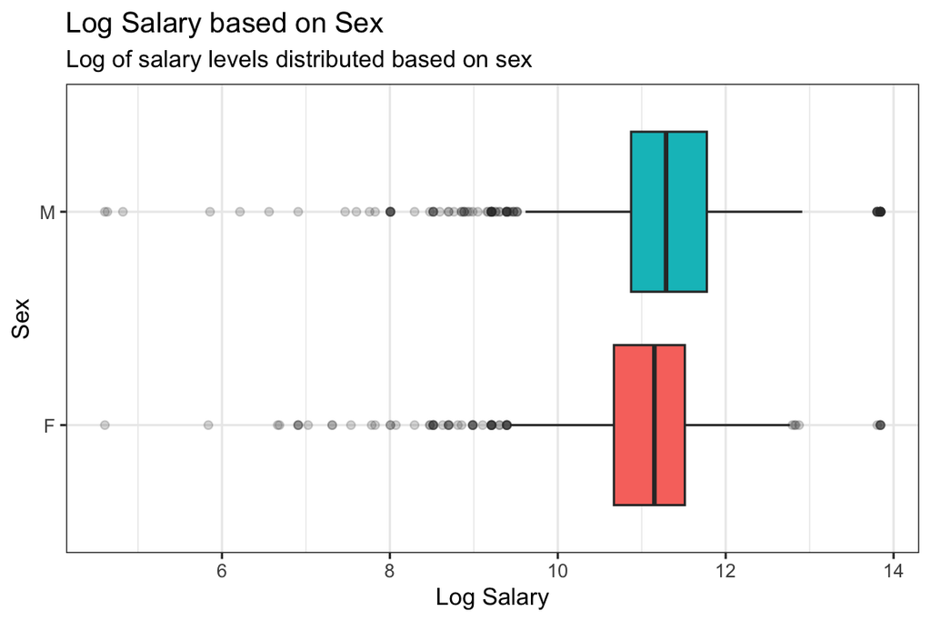

```r
pslog_box <- ggplot(data = ps_log,
                        aes(y = sex,
                            x = log.salary,
                            fill = sex)) +
  geom_boxplot(outlier.alpha = 0.2) +
  labs(x = "Log Salary",
       y = "Sex",
       title = "Log Salary based on Sex",
       subtitle = "Log of salary levels distributed based on sex") +
  theme_bw() +
  theme(legend.position = "none")
pslog_box
```

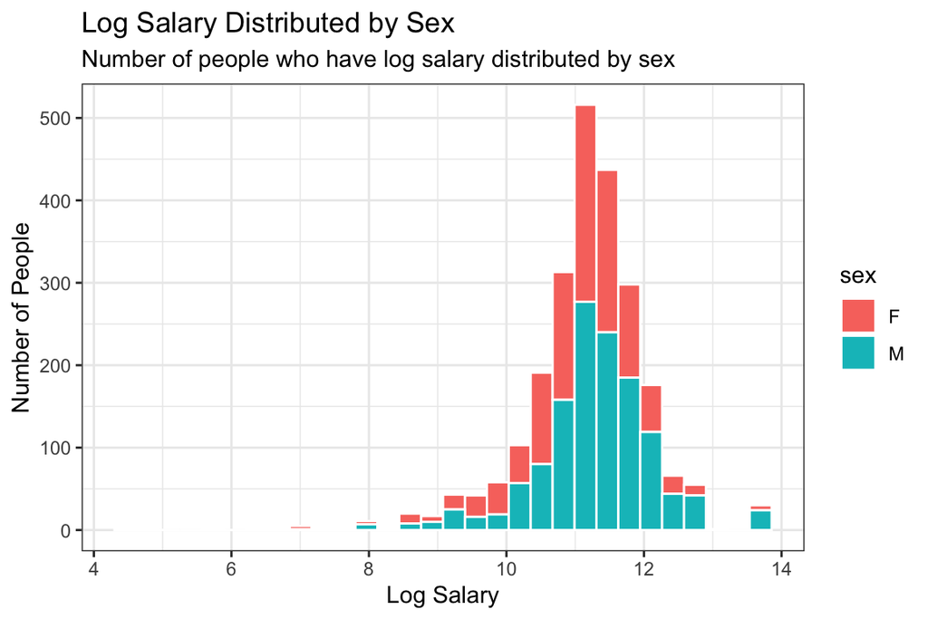

```r
pslog_hist <- ggplot(data = ps_log,
                     aes(x = log.salary,
                         fill = sex)) +
  geom_histogram(color = "white",
                 bins = 30) +
  labs(x = "Log Salary",
       y = "Number of People",
       title = "Log Salary Distributed by Sex",
       subtitle = "Number of people who have log salary distributed by sex") +
  theme_bw()
pslog_hist
```

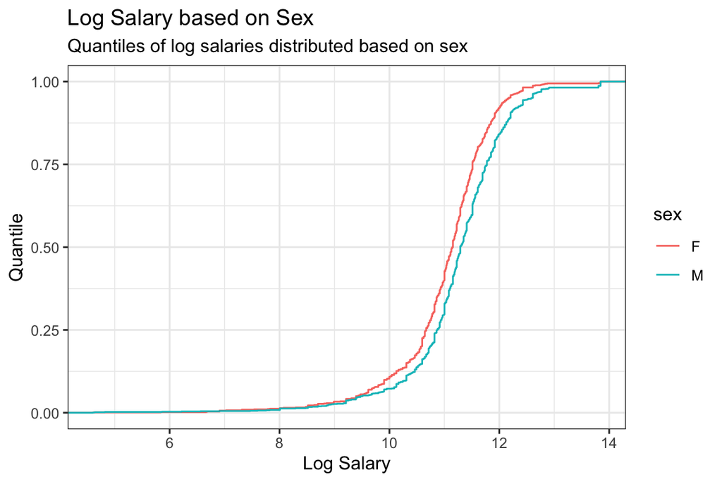

```r
pslog_cdf <- ggplot(data = ps_log,
                    aes(x = log.salary,
                        color = sex)) +
  stat_ecdf() +
  labs(x = "Log Salary",
       y = "Quantile",
       title = "Log Salary based on Sex",
       subtitle = "Quantiles of log salaries distributed based on sex") +
  theme_bw()
pslog_cdf
```

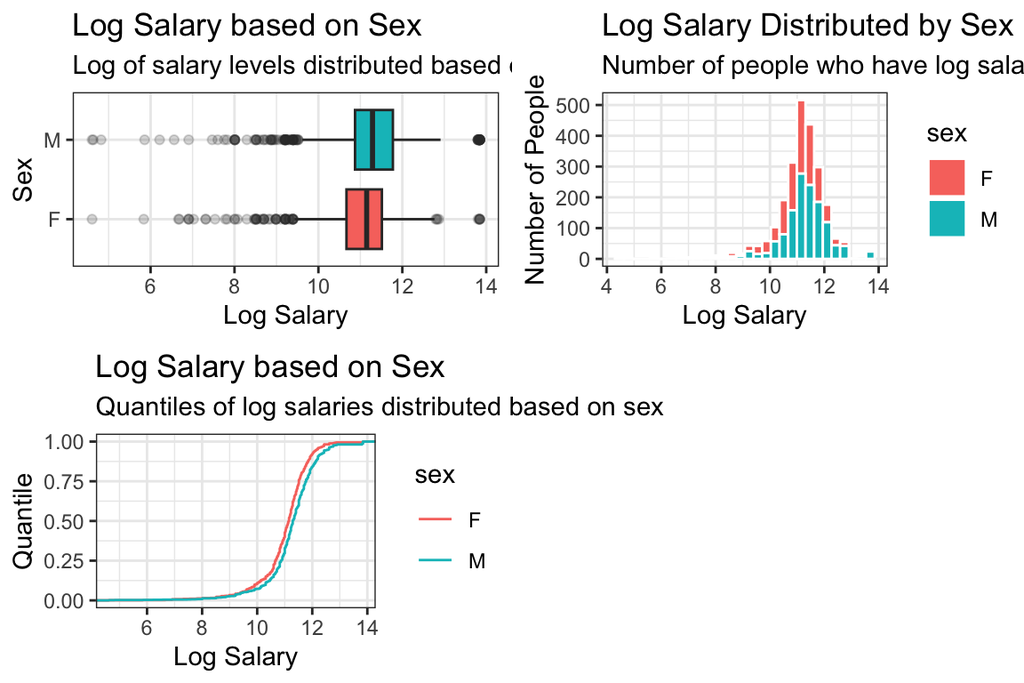

```r
grid.arrange(pslog_box, pslog_hist, pslog_cdf, nrow = 2, ncol = 2)
```

## Question 2

Modify the code that created the `sal_simulate` data frame to create a variable that simulates quantiles from a *cumulative distribution*. Plot these data (instead of a histogram). Hint: instead of `rlnorm()` you will need to use a different log density function that takes a vector of quantiles as input (you will need to specify the quantile vector). Type ?Lognormal into the Console for help.

```r
#fit the data to a lognormal distribution
salary_ps2 <- salary_ps %>%
  dplyr::mutate(salary = salary/100) %>% # salaries now in terms of thousands
  dplyr::filter(salary < 500,
                salary > 10)
fit.plnorm <- fitdistr(salary_ps2$salary, densfun = "log-normal")
fit.plnorm$estimate %>%
  round(.,2)
```

```
## meanlog   sdlog
##    5.49    0.72
```

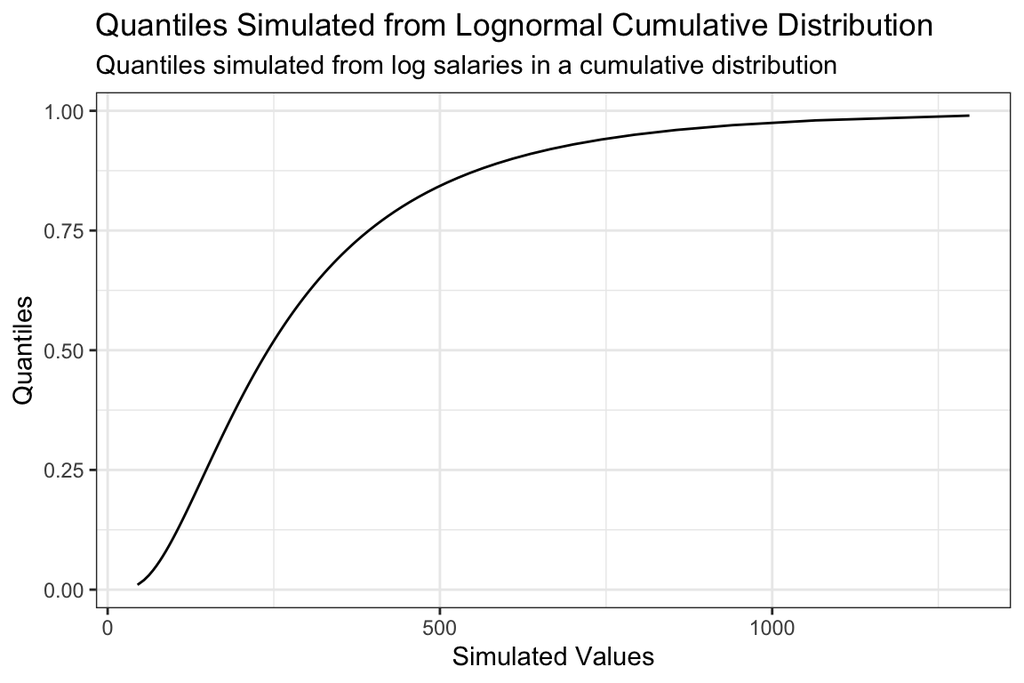

```r
quantiles <- seq(0.01, 0.99, by = 0.01)
sim_vals <- qlnorm(p = quantiles,
                   meanlog = fit.plnorm$estimate[[1]],
                   sdlog = fit.plnorm$estimate[[2]])

sal_simulate1 <- tibble(Quantile = quantiles,
                        Simulated_Values = sim_vals)

ggplot(sal_simulate1,
       aes(x = sim_vals,
           y = Quantile)) +
  geom_line() +
  labs(x = "Simulated Values",
       y = "Quantiles",
       title = "Quantiles Simulated from Lognormal Cumulative Distribution",
       subtitle = "Quantiles simulated from log salaries in a cumulative distribution") +
  theme_bw()
```

## Question 3

Mutate the `salary_ps2` data frame to create a new column variable that takes the log of the salary data (call that variable `log.salary`). Then use `fitdistr()` to fit a *normal distribution* to `log.salary`. What are the resultant parameter estimates for the mean and sd? Hint: the output of `fitdistr()` is a list; look in the `estimate` entry for these parameters. How close are these estimates to those calculated in [section 9.6.4](https://smogdr.github.io/edar_coursebook/transform.html#fit-a-log-normal-distribution) of the Coursebook?

```r
salary_ps2 = salary_ps2 %>%
  dplyr::mutate(log.salary = log(salary))

fitdistr(salary_ps2$salary, "log-normal")
```

```
##     meanlog       sdlog
##   5.48639080   0.72269784
##  (0.02962772) (0.02094996)
```

# Appendix

```r
# set global options for figures, code, warnings, and messages
knitr::opts_chunk$set(fig.width=6, fig.height=4, fig.path="../figs/",
                      echo=TRUE, warning=FALSE, message=FALSE)
# load packages for current session
library(tidyverse)
library(gridExtra) # or library(patchwork) for arranging figures
library(MASS) # for fitting distributions to your data
salary_csv <- "/Users/genevieve/Reyland-MECH476/data/salary_ch9.csv"
salary_ps <- read_csv(file = salary_csv)

salary_ps %>%
  group_by(sex) %>%
  summarise(median = median(salary),
            mean = mean(salary),
            min = min(salary),
            max = max(salary),
            IQR = IQR(salary),
            .groups = "keep") %>%
  ungroup()

ps_log <- salary_ps %>%
  mutate(log.salary = log(salary))
pslog_box <- ggplot(data = ps_log,
                        aes(y = sex,
                            x = log.salary,
                            fill = sex)) +
  geom_boxplot(outlier.alpha = 0.2) +
  labs(x = "Log Salary",
       y = "Sex",
       title = "Log Salary based on Sex",
       subtitle = "Log of salary levels distributed based on sex") +
  theme_bw() +
  theme(legend.position = "none")
pslog_box

pslog_hist <- ggplot(data = ps_log,
                     aes(x = log.salary,
                         fill = sex)) +
  geom_histogram(color = "white",
                 bins = 30) +
  labs(x = "Log Salary",
       y = "Number of People",
       title = "Log Salary Distributed by Sex",
       subtitle = "Number of people who have log salary distributed by sex") +
  theme_bw()
pslog_hist

pslog_cdf <- ggplot(data = ps_log,
                    aes(x = log.salary,
                        color = sex)) +
  stat_ecdf() +
  labs(x = "Log Salary",
       y = "Quantile",
       title = "Log Salary based on Sex",
       subtitle = "Quantiles of log salaries distributed based on sex") +
  theme_bw()
pslog_cdf

grid.arrange(pslog_box, pslog_hist, pslog_cdf, nrow = 2, ncol = 2)
#fit the data to a lognormal distribution
salary_ps2 <- salary_ps %>%
  dplyr::mutate(salary = salary/100) %>% # salaries now in terms of thousands
  dplyr::filter(salary < 500,
                salary > 10)
fit.plnorm <- fitdistr(salary_ps2$salary, densfun = "log-normal")
fit.plnorm$estimate %>%
  round(.,2)
quantiles <- seq(0.01, 0.99, by = 0.01)
sim_vals <- qlnorm(p = quantiles,
                   meanlog = fit.plnorm$estimate[[1]],
                   sdlog = fit.plnorm$estimate[[2]])

sal_simulate1 <- tibble(Quantile = quantiles,
                        Simulated_Values = sim_vals)

ggplot(sal_simulate1,
       aes(x = sim_vals,
           y = Quantile)) +
  geom_line() +
  labs(x = "Simulated Values",
       y = "Quantiles",
       title = "Quantiles Simulated from Lognormal Cumulative Distribution",
       subtitle = "Quantiles simulated from log salaries in a cumulative distribution") +
  theme_bw()

salary_ps2 = salary_ps2 %>%
  dplyr::mutate(log.salary = log(salary))

fitdistr(salary_ps2$salary, "log-normal")
```